# What controls the range of hosts a fish parasite infects?

Tad Dallas, Andrew Park, and John M. Drake

### Knowledge gap

- What constrains the range of hosts that a parasite can infect? Is there a simple range of host functional traits that can determine the likelihood that a parasite infects a given host species? How well can we predict parasite occurrences given host life history traits? How about using solely information on parasite community structure?
- Does the importance of different host functional traits or parasite community information differ with parasite type? (supplement)
- Since geographic variables are important, what if we try to predict parasite niche breadth in a specific biogeographic region? (supplement)

### Thesis paragraph

Here, I apply a series of predictive models in order to predict parasite occurrence across a range of potential host species for a large set of parasites of freshwater fish, using host functional traits, geographic location, and parasite community information. Parasite occurrence on a given host could be constrained by space (geographic location), patch quality (host characteristics), or through interactions with competing parasites (parasite community structure). It’s important to note right up front that the importance of parasite community structure cannot be interpreted as evidence for community interactions, as parasites could infect hosts based on their traits, and the parasite community information could just be serving as a proxy for unmeasured host trait variation. However, predicting parasite occurrence based solely on parasite community information does remove some importance of the patch (host), and is easy to sell, as it may be possible to predict spillover of parasites, or the degree of biotic resistance a community offers to a potential invader, simply by having presence-absence data on parasite communities.

I examine the role of parasite group (Acanthocephala, Cestoda, Monogenea, Nematoda, Trematoda) on model performance, and on the relative contribution of different variables to prediction.

## Methods

### Model formulation

We trained a series of models in order to compare predictive performance of different techniques. Each model was trained on 70% of the data, and accuracy was determined from the remaining 30%. This process was repeated $z$ times ($z$ = 20). We generated background data by randomly sampling host species where parasite $i$ was not recorded. To maintain proportional training data, the number of random samples was selected to be five times greater than the occurrence records.

### Models used

#### Training using only host trait data

#### Training using only geographic

#### Training using only parasite community data

#### Training using all data

*** Run this model again ***

```r
#Calulate other types of accuracy measures
brt.perfAcc.traits=vector(); brt.perfAcc.geo=vector();
brt.perfAcc.pars=vector(); brt.perfAcc.all=vector();
base.perfAcc=vector()

brt.perferr.traits=vector(); brt.perferr.geo=vector();
brt.perferr.pars=vector(); brt.perferr.all=vector();
base.perferr=vector()

brt.perfmxe.traits=vector(); brt.perfmxe.geo=vector();
brt.perfmxe.pars=vector(); brt.perfmxe.all=vector();
base.perfmxe=vector()

for(z in 1:length(brtModel)){
    brt.perfAcc.traits[z] = max(unlist(performance(brt.preds[[z]],measure = 'acc')@y.values))
    brt.perfAcc.geo[z]=max(unlist(performance(brt.preds.geo[[z]],measure = 'acc')@y.values))
    brt.perfAcc.pars[z]=max(unlist(performance(brt.preds.b[[z]],measure = 'acc')@y.values))
    brt.perfAcc.all[z]=max(unlist(performance(brt.preds.c[[z]],measure = 'acc')@y.values))
    base.perfAcc[z]=max(unlist(performance(prediction(sample(presence[-inds], length(presence[-inds])), presence[-inds]), 'acc')@y.values))

    brt.perferr.traits[z] = min(unlist(performance(brt.preds[[z]],measure = 'err')@y.values))
    brt.perferr.geo[z]=min(unlist(performance(brt.preds.geo[[z]],measure = 'err')@y.values))
    brt.perferr.pars[z]=min(unlist(performance(brt.preds.b[[z]],measure = 'err')@y.values))
    brt.perferr.all[z]=min(unlist(performance(brt.preds.c[[z]],measure = 'err')@y.values))
    base.perferr[z]=min(unlist(performance(prediction(sample(presence[-inds], length(presence[-inds])), presence[-inds]), 'err')@y.values))

    brt.perfmxe.traits[z] = max(unlist(performance(brt.preds[[z]],measure = 'prec')@y.values))
    brt.perfmxe.geo[z]=max(unlist(performance(brt.preds.geo[[z]],measure = 'prec')@y.values))
    brt.perfmxe.pars[z]=max(unlist(performance(brt.preds.b[[z]],measure = 'prec')@y.values))
    brt.perfmxe.all[z]=max(unlist(performance(brt.preds.c[[z]],measure = 'prec')@y.values))
    base.perfmxe[z]=max(unlist(performance(prediction(sample(presence[-inds], length(presence[-inds])), presence[-inds]), 'prec')@y.values))


   print(z)

}
```

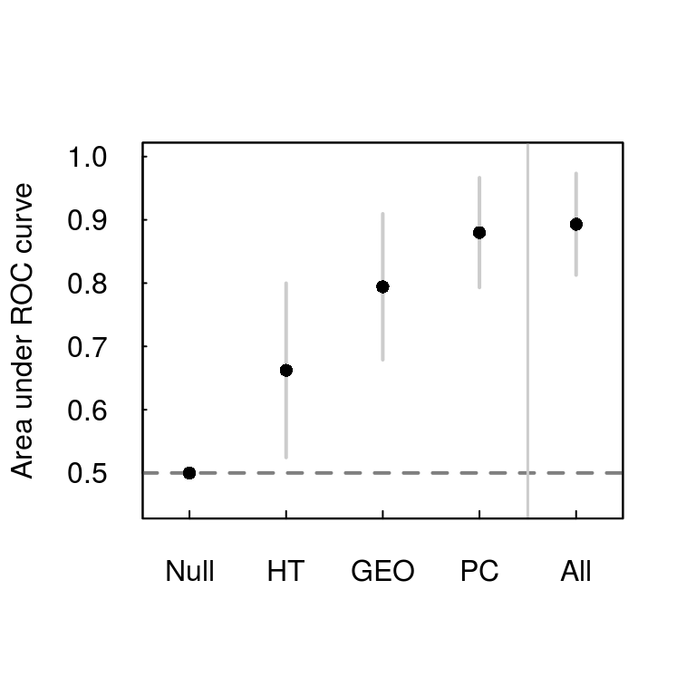

```r
testRet = apply(as.matrix(ret), 2, as.numeric)
testRetb = apply(as.matrix(ret.b), 2, as.numeric)
testRetc = apply(as.matrix(ret.c), 2, as.numeric)
testRetgeo = apply(as.matrix(ret.geo), 2, as.numeric)

meanAUC = colMeans(testRet)
meanSE = apply(testRet, 2, sd)/sqrt(nrow(testRet))
meanSD = apply(testRet, 2, sd)

meanAUC.b = colMeans(testRetb)
meanSE.b = apply(testRetb, 2, sd)/sqrt(nrow(testRetb))
meanSD.b = apply(testRetb, 2, sd)

meanAUC.c = colMeans(testRetc)
meanSE.c = apply(testRetc, 2, sd)/sqrt(nrow(testRetc))
meanSD.c = apply(testRetc, 2, sd)

meanAUC.geo = colMeans(testRetgeo)
meanSE.geo = apply(testRetgeo, 2, sd)/sqrt(nrow(testRetgeo))
meanSD.geo = apply(testRetgeo, 2, sd)

brt.zero = c(meanAUC[1], meanAUC.geo[1], meanAUC.b[1], meanAUC.c[1])
brt.zero.se = c(meanSE[1], meanSE.geo[1], meanSE.b[1], meanSE.c[1])
brt.zero.sd = c(meanSD[1], meanSD.geo[1], meanSD.b[1], meanSD.c[1])

brt.meanAUC = c(meanAUC[3], meanAUC.geo[3], meanAUC.b[3], meanAUC.c[3])
brt.se = c(meanSE[3], meanSE.geo[3], meanSE.b[3], meanSE.c[3])
brt.sd = c(meanSD[3], meanSD.geo[3], meanSD.b[3], meanSD.c[3])


plot(1:5, c(mean(brt.zero), brt.meanAUC), ylim = c(0.45, 1), xlim = c(0.7, 5.3),
    las = 1, pch = 16, tck = 0.01, xaxt = "n", xlab = "", ylab = "Area under ROC curve")

abline(h = 0.5, col = grey(0.5), lty = 2, lwd = 2)
abline(v = 4.5, col = grey(0.8), lwd = 1.5)
segments(x0 = 2:5, y0 = brt.meanAUC + (brt.sd), y1 = brt.meanAUC - (brt.sd),
    col = grey(0.8), lwd = 2)
segments(x0 = 1, y0 = mean(brt.zero) + mean(brt.zero.sd), y1 = mean(brt.zero) -
    mean(brt.zero.sd))
points(1:5, c(mean(brt.zero), brt.meanAUC), pch = 16, cex = 1)
axis(1, at = 1:5, labels = c("Null", "HT", "GEO", "PC", "All"), tck = 0.02,
    lwd = 1)
box()
```

```r
dev.copy(pdf, width = 3.6, height = 3.6, "../Manuscript/Figures/brtAccuracy.pdf")
```

```r
dev.off()
```

### Does predictive power differ systematically among parasites?

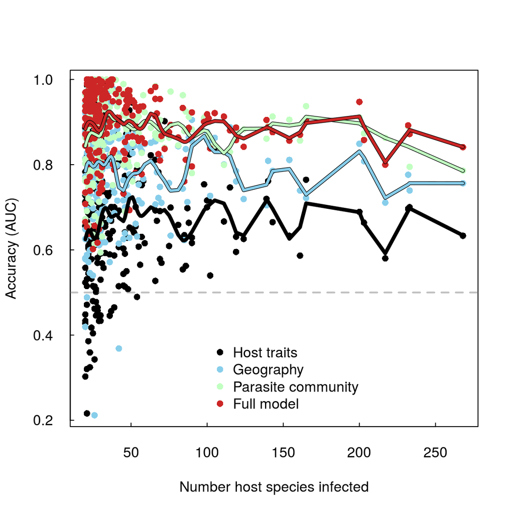

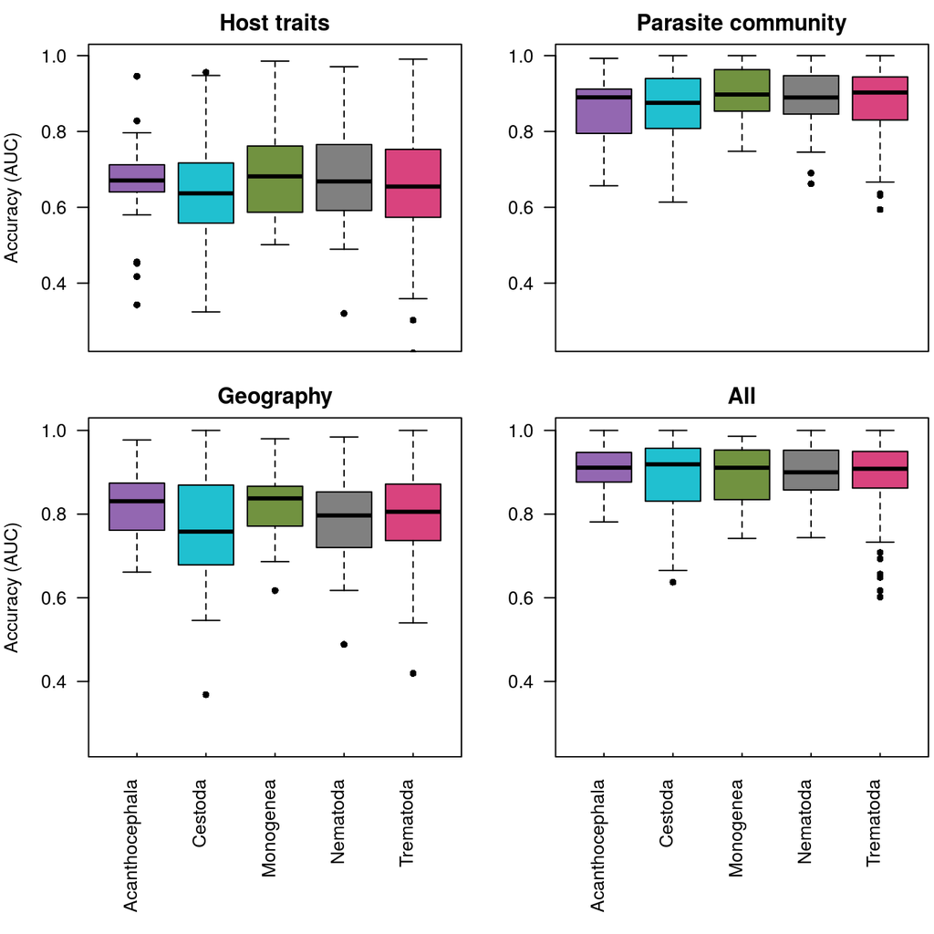

```r
layout(matrix(c(1,2,3,4), ncol=2), heights=c(1,1.5))

hostCol=c('#9367B1', '#20C0D0','#719240', grey(0.5), '#D9437E')
par(mar=c(1,4,2,0.25))
plot(as.factor(parType[,1]), testRet[1:238,3], col=hostCol, tck=0.01, pch=16, las=1, ylab='Accuracy (AUC)', xaxt='n', ylim=c(0.25,1), main="Host traits")

par(mar=c(8,4,2,0.25))
plot(as.factor(parType[,1]), testRetgeo[1:238,3], col=hostCol, tck=0.01, pch=16, las=1, ylab='Accuracy (AUC)', xaxt='n', ylim=c(0.25,1), main="Geography")
parGroups=c('Acanthocephala', 'Cestoda', 'Monogenea', 'Nematoda', 'Trematoda')
axis(1, 1:5, parGroups, las=2, tck=0.01, padj=0)

par(mar=c(1,4,2,0.25))
plot(as.factor(parType[,1]), testRetb[1:238,3], col=hostCol, tck=0.01,pch=16, las=1, ylab='', xaxt='n', ylim=c(0.25,1), main="Parasite community")

par(mar=c(8,4,2,0.25))
plot(as.factor(parType[,1]), testRetc[1:238,3], col=hostCol, pch=16, tck=0.01, las=1, ylab='', xaxt='n', ylim=c(0.25,1), main="All")
parGroups=c('Acanthocephala', 'Cestoda', 'Monogenea', 'Nematoda', 'Trematoda')
axis(1, 1:5, parGroups, las=2, tck=0.01, padj=0)
```

```r
dev.copy(pdf, width=5, height=5, '../Manuscript/Figures/parAccuracy.pdf'); dev.off()
```

### Are parasite distributions shaped by different factors?

#### BRT model using only host traits

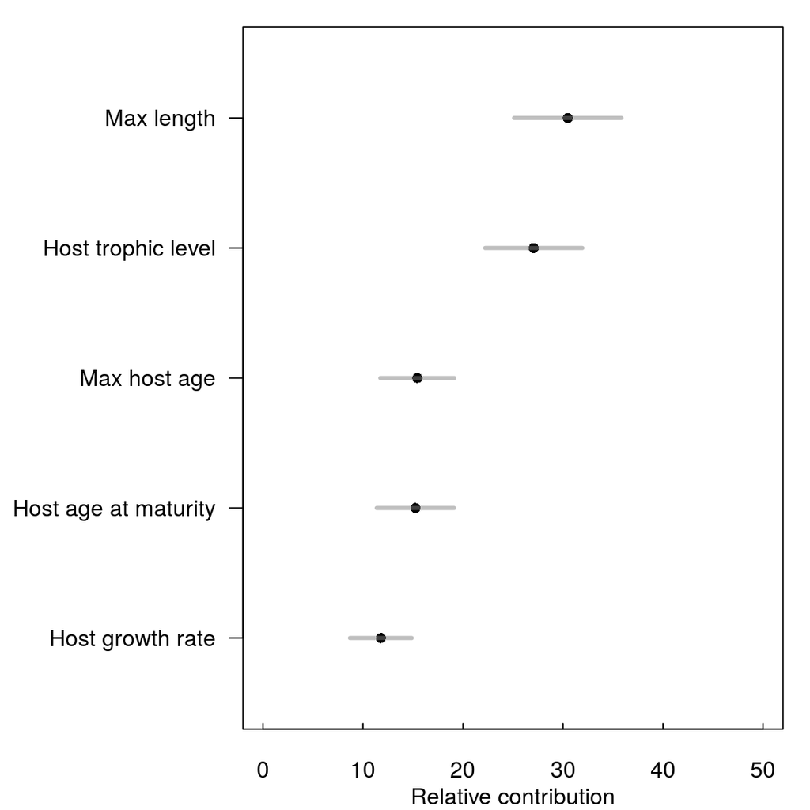

```r
#varNames=c('Geographic region', 'Area of occupancy', 'Latitude', 'Max length', 'Host trophic level', 'Longitude', 'Host age at maturity', 'Host life span', 'Host growth rate', 'Marine', 'Freshwater', 'Brackish')

brtMean = rowMeans(brtResults.traits)
brtSE = apply(brtResults.traits, 1, sd) / sqrt(ncol(brtResults.traits))
brtSD = apply(brtResults.traits, 1, sd)

inds.a=order(brtMean)
par(mar=c(3,9,1,1))
plot(brtMean[inds.a], 1:5, pch=16, xlim=c(0,50), ylim=c(0.5,5.5), las=1, xlab='', ylab='', yaxt='n', col=1, tck=0.01)
segments(x0=brtMean[inds.a] - brtSD[inds.a], x1=brtMean[inds.a] + brtSD[inds.a], y0=1:5, col=grey(0.5,0.5),lwd=3)
mtext("Relative contribution", side=1, line=2)
axis(2, at=1:5, labels=c('Host growth rate', 'Host age at maturity', 'Max host age', 'Host trophic level', 'Max length'), las=1)
```

```r
dev.copy(pdf, width=6, height=5, '../Manuscript/Figures/hostTraits.pdf'); dev.off()
```

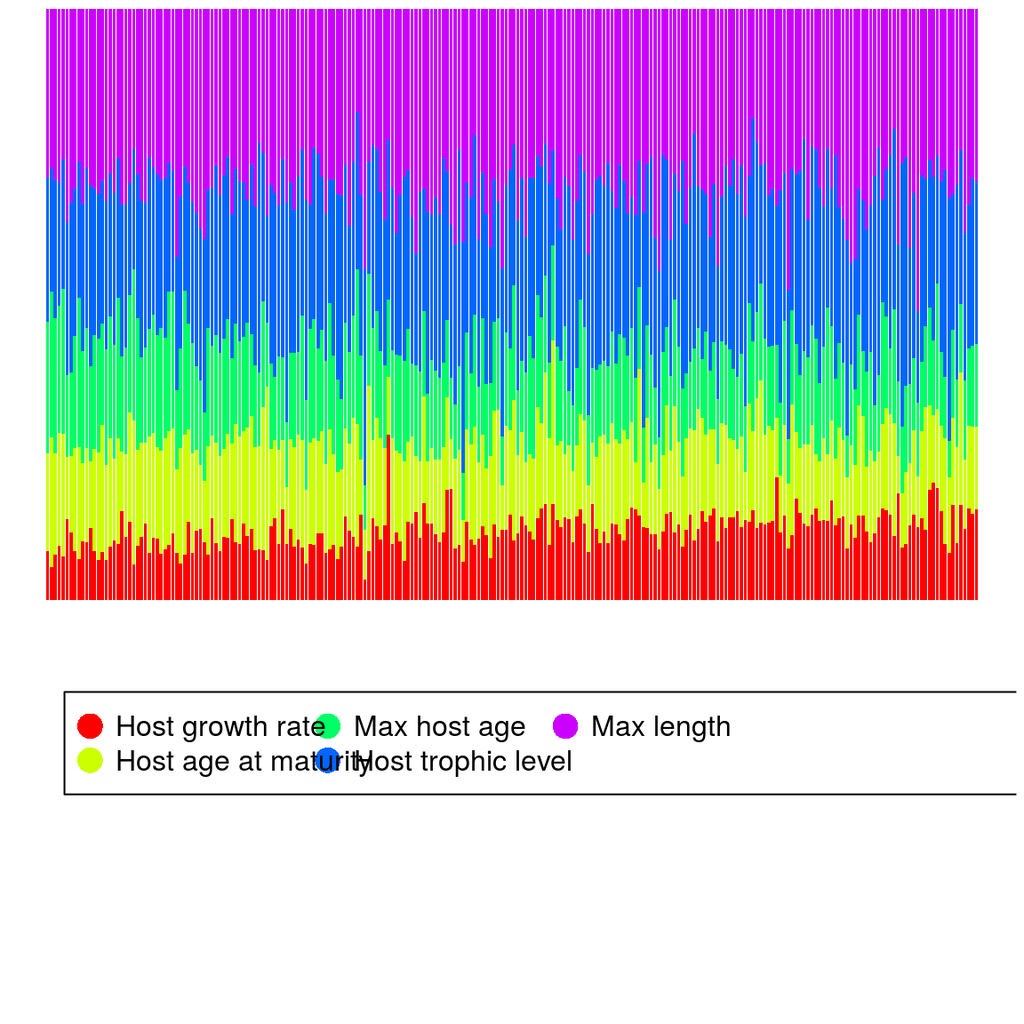

```r
layout(matrix(c(1,2),ncol=1), heights=c(1.5, 1))
par(mar=c(0.25,0.25,0.25,0.25))
barplot(brtResults.traits[inds.a,], col=rainbow(5), xaxt='n', axes=FALSE, border = NA)
plot.new()
legend(0.02,0.85, c('Host growth rate', 'Host age at maturity', 'Max host age', 'Host trophic level', 'Max length'), pch=16, col=rainbow(5), ncol=4, pt.cex=2, text.width=0.2)
```

```r
dev.copy(pdf, width=7, height=5, '../Manuscript/Figures/hostTraitsColor.pdf'); dev.off()
```

#### BRT model using only geographic variables

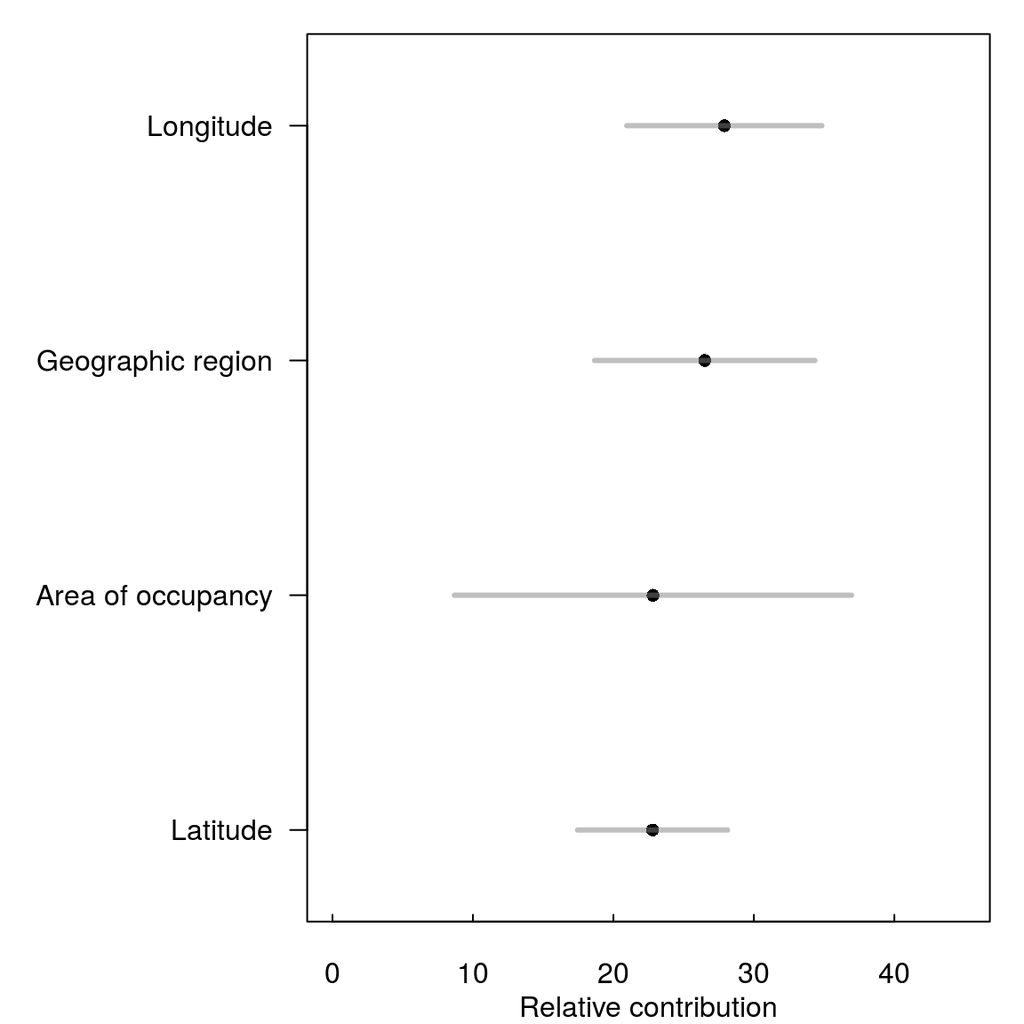

```r
varNames=c('Geographic region', 'Area of occupancy', 'Latitude', 'Max length', 'Host trophic level', 'Longitude', 'Host age at maturity', 'Host life span', 'Host growth rate', 'Marine', 'Freshwater', 'Brackish')
#rownames(brtResults[rev(inds),])]

brtMean = rowMeans(brtResults.geo)
brtSE = apply(brtResults.geo, 1, sd) / sqrt(ncol(brtResults.geo))
brtSD = apply(brtResults.geo, 1, sd)

inds.a=order(brtMean)
par(mar=c(3,9,1,1))
plot(brtMean[inds.a], 1:4, pch=16, xlim=c(0,45), ylim=c(0.75,4.25), las=1, xlab='', ylab='', yaxt='n', col=1, tck=0.01)
segments(x0=brtMean[inds.a] - brtSD[inds.a], x1=brtMean[inds.a] + brtSD[inds.a], y0=1:4, col=grey(0.5,0.5),lwd=3)
mtext("Relative contribution", side=1, line=2)
axis(2, at=1:4, labels=c('Latitude', 'Area of occupancy', 'Geographic region', 'Longitude'), las=1)
```

```r
dev.copy(pdf, width=6, height=5, '../Manuscript/Figures/geography.pdf'); dev.off()
```

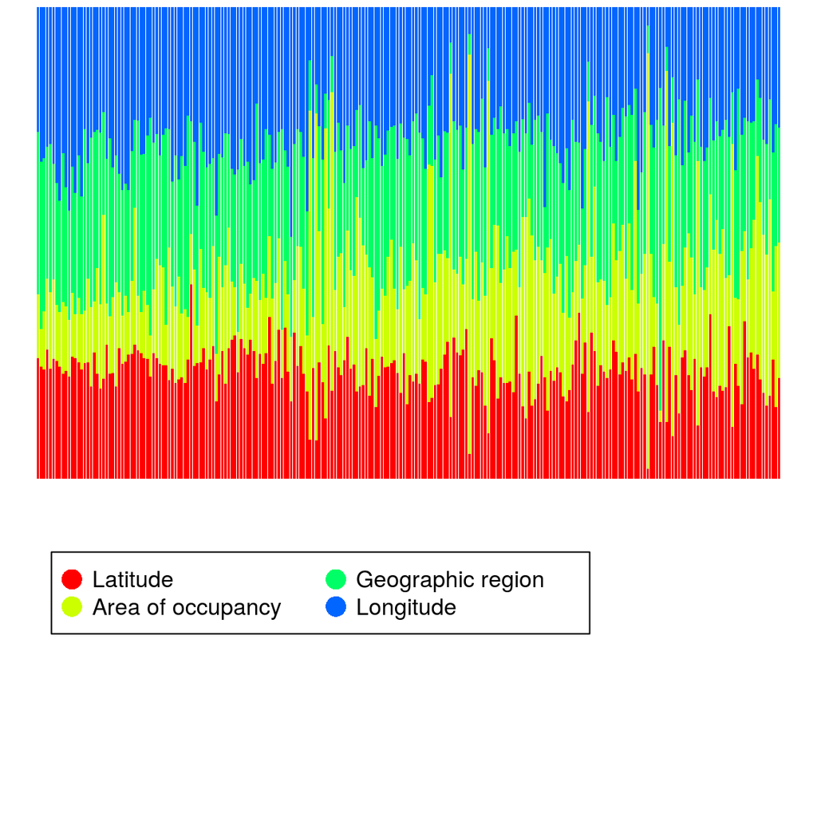

```r
layout(matrix(c(1,2),ncol=1), heights=c(1.5, 1))
par(mar=c(0.25,0.25,0.25,0.25))
barplot(brtResults.geo[inds.a,], col=rainbow(5), xaxt='n', axes=FALSE, border = NA)
plot.new()
legend(0.02,0.85, c('Latitude', 'Area of occupancy', 'Geographic region', 'Longitude'), pch=16, col=rainbow(5), ncol=2, pt.cex=2, text.width=0.3)
```

```r
dev.copy(pdf, width=7, height=5, '../Manuscript/Figures/geographyColor.pdf'); dev.off()
```

#### BRT models using only parasite community data (parasite species richness and a PCA of parasite community composition)

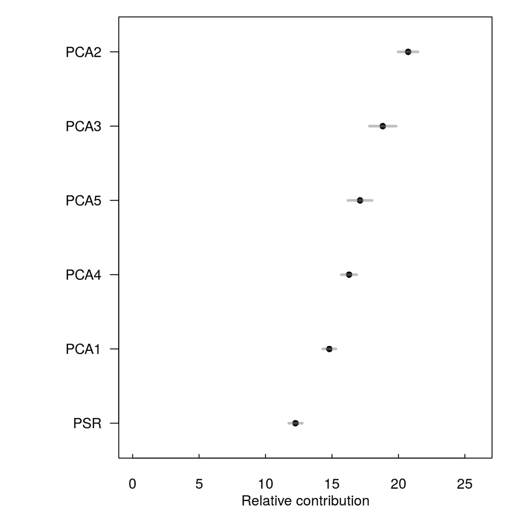

```r
brtMean.b = rowMeans(brtResults.pars)
brtSE.b = apply(brtResults.pars, 1, sd) / sqrt(ncol(brtResults.pars))
brtSD.b = apply(brtResults.pars, 1, sd)

inds=order(brtMean.b)
par(mar=c(3,7,1,1))
plot(brtMean.b[inds], 1:6, pch=16, xlim=c(0,26), ylim=c(0.75,6.25), las=1, xlab='', ylab='', yaxt='n', col=1, tck=0.01)
segments(x0=brtMean.b[inds] - brtSE.b[inds], x1=brtMean.b[inds] + brtSE.b[inds], y0=1:6, col=grey(0.5, alpha=0.5),lwd=3)
mtext("Relative contribution", side=1, line=2)
axis(2, at=1:6, labels=rev(c('PCA2', 'PCA3', 'PCA5', 'PCA4', 'PCA1', 'PSR')), las=1)
```

```r
dev.copy(pdf, width=6, height=5, '../Manuscript/Figures/parasiteCommunity.pdf'); dev.off()
```

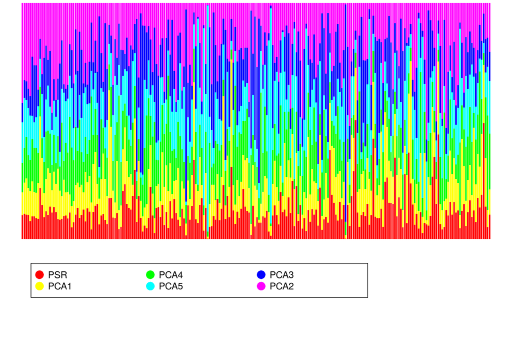

```r
layout(matrix(c(1,2),ncol=1), heights=c(2.5, 1))
par(mar=c(0.25,0.25,0.25,0.25))
barplot(brtResults.pars[inds,], col=rainbow(6), xaxt='n', axes=FALSE, border = NA)
plot.new()
legend(0.02,0.85, rev(c('PCA2', 'PCA3', 'PCA5', 'PCA4', 'PCA1', 'PSR')), pch=16, col=rainbow(6), ncol=3, pt.cex=2, text.width=0.2)
```

```r
dev.copy(pdf, width=7, height=5, '../Manuscript/Figures/parasiteCommunityColor.pdf'); dev.off()
```

#### BRT models trained on all data

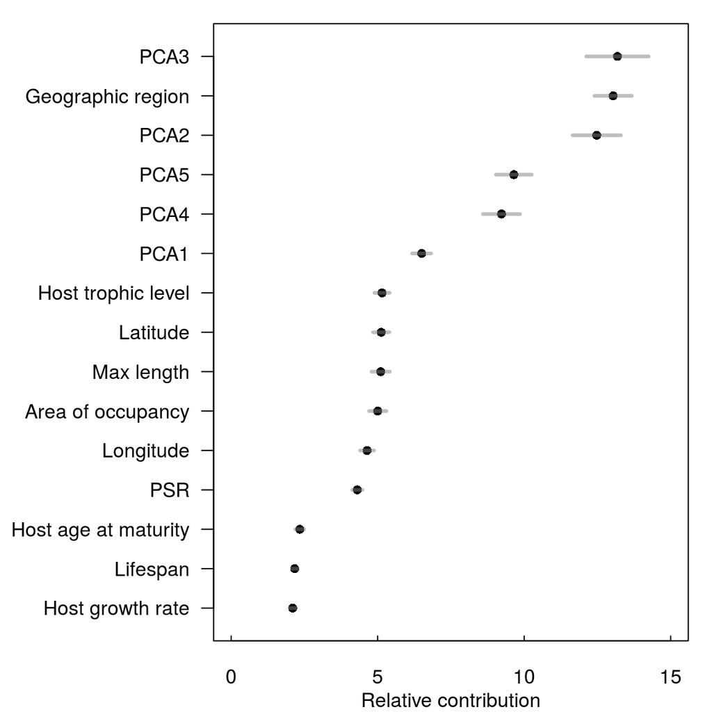

```r
brtMean.c = rowMeans(brtResults.all)
brtSE.c = apply(brtResults.all, 1, sd) / sqrt(ncol(brtResults.all))
brtSD.c = apply(brtResults.all, 1, sd)

inds=order(brtMean.c)
par(mar=c(3,9,1,1))
plot(brtMean.c[inds], 1:15, pch=16, xlim=c(0,15), ylim=c(0.75,15.25), las=1, xlab='', ylab='', yaxt='n', col=1, tck=0.01)
segments(x0=brtMean.c[inds] - brtSE.c[inds], x1=brtMean.c[inds] + brtSE.c[inds], y0=1:18, col=grey(0.5, alpha=0.5),lwd=3)
mtext("Relative contribution", side=1, line=2)
axis(2, at=1:15, labels=c('Host growth rate', 'Lifespan', 'Host age at maturity', 'PSR', 'Longitude', 'Area of occupancy', 'Max length', 'Latitude', 'Host trophic level', 'PCA1', 'PCA4', 'PCA5', 'PCA2', 'Geographic region', 'PCA3'),las=1)
```

```r
dev.copy(pdf, width=6, height=5, '../Manuscript/Figures/allData.pdf'); dev.off()
```

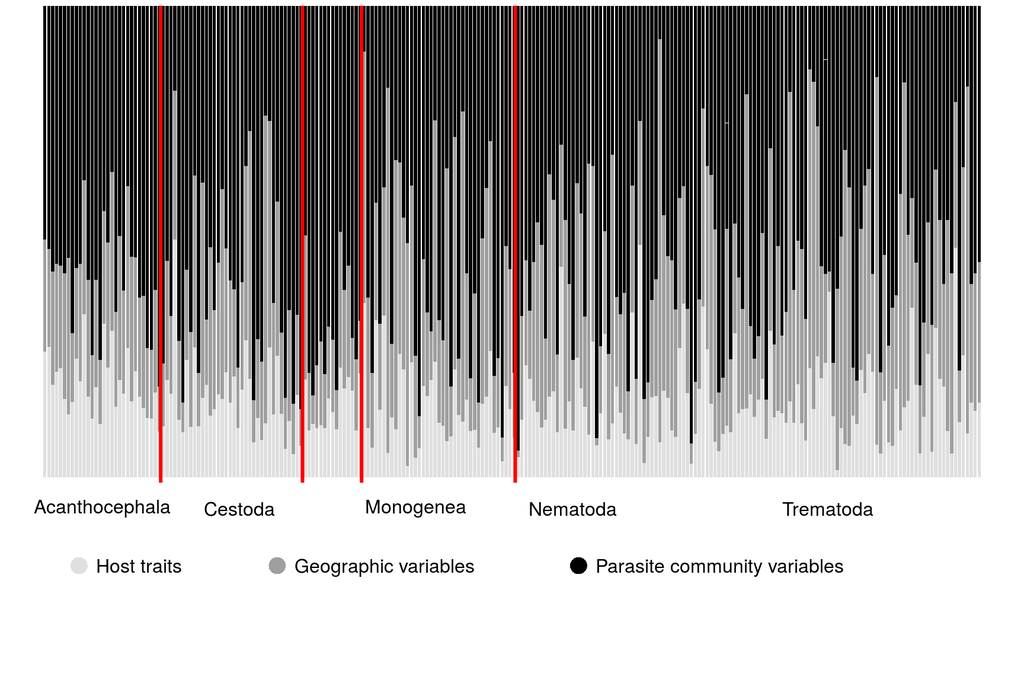

```r
cols=c('#7EC0EE',  '#32CD32', '#CD3232')
greycols=c(grey(0.75,0.5), grey(0.25,0.5), 'black')
#inds=order(brtMean.c)
inds=c(1,2,1,1,1,2,3,2,3,3,3,3,3,2,2)
layout(matrix(c(1,2),ncol=1), heights=c(2.5, 1))
par(mar=c(0.25,0.25,0.25,0.25))
barplot(brtResults.all[order(inds),], col=greycols[c(1,1,1,1,2,2,2,2,2,3,3,3,3,3,3)], xaxt='n', axes=FALSE, border = NA)

parGroups=c('Acanthocephala', 'Cestoda', 'Monogenea', 'Nematoda', 'Trematoda')

abline(v=c(30,66,81,120)*1.199, lwd=3, col='red')
plot.new()
text(15/239, 0.95 , parGroups[1],srt=0)
text(50/239, 0.95 , parGroups[2], srt=0)
text(95/239, 0.95 , parGroups[3], srt=0)
text(135/239,0.95 , parGroups[4], srt=0)
text(200/239,0.95 , parGroups[5], srt=0)

legend(0.02,0.75, c('Host traits', 'Geographic variables', 'Parasite community variables'), col=greycols, ncol=3, pt.cex=2, text.width=c(0, 0.175,0.23), pch=16, bty='n')
```

```r
#legend(0.02,0.85, c('Brackish', 'Marine', 'Freshwater', 'Host growth rate', 'Lifespan', 'Host age at maturity', 'PSR', 'Longitude', 'Area of occupancy', 'Max length', 'Latitude', 'Host trophic level', 'PCA1', 'PCA4', 'PCA5', 'PCA2', 'Geographic region', 'PCA3') , pch=16, col=rainbow(20), ncol=4, pt.cex=2, text.width=0.2)

dev.copy(pdf, width=7, height=5, '../Manuscript/Figures/allDataColorGS.pdf'); dev.off()
```

## MEGA PLOT!

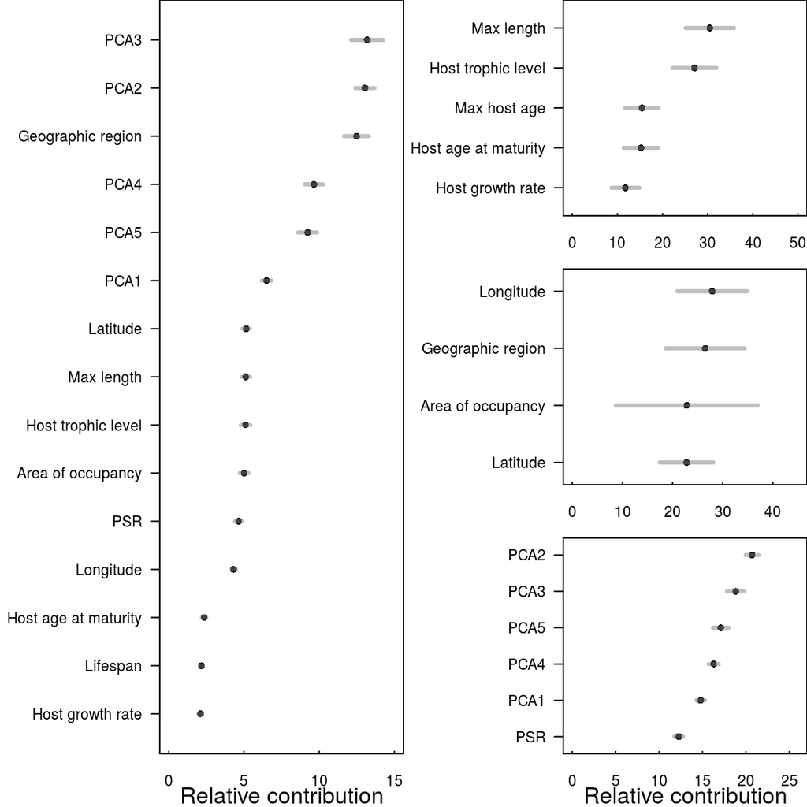

```r
layout(matrix(c(1,1,1,2,3,4), ncol=2))

#plot 1 (all traits)
brtMean.c = rowMeans(brtResults.all)
brtSE.c = apply(brtResults.all, 1, sd) / sqrt(ncol(brtResults.all))
brtSD.c = apply(brtResults.all, 1, sd)

inds=order(brtMean.c)
par(mar=c(3,9,0,0))
plot(brtMean.c[inds], 1:15, pch=16, xlim=c(0,15), ylim=c(0.75,15.25), las=1, xlab='', ylab='', yaxt='n', col=1, tck=0.01)
segments(x0=brtMean.c[inds] - brtSE.c[inds], x1=brtMean.c[inds] + brtSE.c[inds], y0=1:15, col=grey(0.5, alpha=0.5),lwd=3)
mtext("Relative contribution", side=1, line=2)
axis(2, at=1:15, labels=c('Host growth rate', 'Lifespan', 'Host age at maturity', 'Longitude', 'PSR', 'Area of occupancy', 'Host trophic level', 'Max length', 'Latitude', 'PCA1', 'PCA5', 'PCA4', 'Geographic region', 'PCA2', 'PCA3'),las=1)






#plot2 (host traits)
brtMean = rowMeans(brtResults.traits)
brtSE = apply(brtResults.traits, 1, sd) / sqrt(ncol(brtResults.traits))
brtSD = apply(brtResults.traits, 1, sd)

inds.a=order(brtMean)
par(mar=c(3,9,0,0))
plot(brtMean[inds.a], 1:5, pch=16, xlim=c(0,50), ylim=c(0.5,5.5), las=1, xlab='', ylab='', yaxt='n', col=1, tck=0.01)
segments(x0=brtMean[inds.a] - brtSD[inds.a], x1=brtMean[inds.a] + brtSD[inds.a], y0=1:5, col=grey(0.5,0.5),lwd=3)
axis(2, at=1:5, labels=c('Host growth rate', 'Host age at maturity', 'Max host age', 'Host trophic level', 'Max length'), las=1)


#plot3 (geographic vars)
brtMean = rowMeans(brtResults.geo)
brtSE = apply(brtResults.geo, 1, sd) / sqrt(ncol(brtResults.geo))
brtSD = apply(brtResults.geo, 1, sd)

inds.a=order(brtMean)
par(mar=c(3,9,0,0))
plot(brtMean[inds.a], 1:4, pch=16, xlim=c(0,45), ylim=c(0.75,4.25), las=1, xlab='', ylab='', yaxt='n', col=1, tck=0.01)
segments(x0=brtMean[inds.a] - brtSD[inds.a], x1=brtMean[inds.a] + brtSD[inds.a], y0=1:4, col=grey(0.5,0.5),lwd=3)
axis(2, at=1:4, labels=c('Latitude', 'Area of occupancy', 'Geographic region', 'Longitude'), las=1)


#plot4 (parasite community)

brtMean.b = rowMeans(brtResults.pars)
brtSE.b = apply(brtResults.pars, 1, sd) / sqrt(ncol(brtResults.pars))
brtSD.b = apply(brtResults.pars, 1, sd)

inds=order(brtMean.b)
par(mar=c(3,9,0,0))
plot(brtMean.b[inds], 1:6, pch=16, xlim=c(0,26), ylim=c(0.75,6.25), las=1, xlab='', ylab='', yaxt='n', col=1, tck=0.01)
segments(x0=brtMean.b[inds] - brtSE.b[inds], x1=brtMean.b[inds] + brtSE.b[inds], y0=1:6, col=grey(0.5, alpha=0.5),lwd=3)
mtext("Relative contribution", side=1, line=2)
axis(2, at=1:6, labels=rev(c('PCA2', 'PCA3', 'PCA5', 'PCA4', 'PCA1', 'PSR')), las=1)
```

```r
dev.copy(pdf, width=6, height=4, '../Manuscript/Figures/megaBRT.pdf'); dev.off()
```

### Is this variation attributable to parasite type?

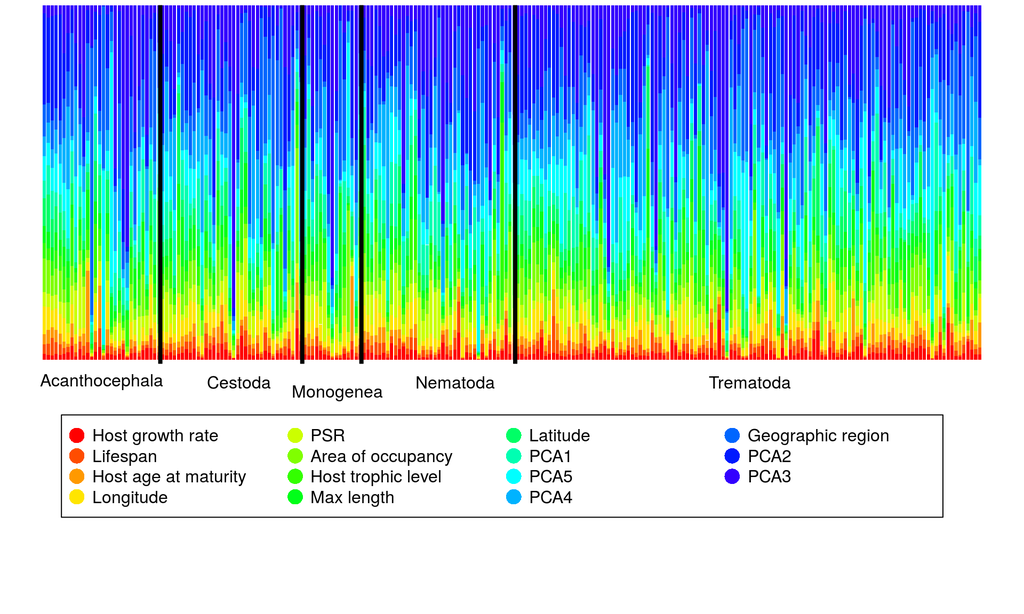

```r
layout(matrix(c(1,2),ncol=1), heights=c(1.5, 1))
par(mar=c(0.25,0.25,0.25,0.25))
inds=order(brtMean.c)
brtResults.ParType=brtResults.all[inds,order(parType[,1])]

barplot(brtResults.ParType, col=rainbow(20), xaxt='n', axes=FALSE, border = NA)
abline(v=c(30,66,81,120)*1.199, lwd=4)
plot.new()
text(15/239, 1 , parGroups[1],srt=0)
text(50/239, 1, parGroups[2], srt=0)
text(75/239, 0.95, parGroups[3], srt=0)
text(105/239, 1, parGroups[4], srt=0)
text(180/239, 1, parGroups[5], srt=0)


legend(0.02,0.85, c('Host growth rate', 'Lifespan', 'Host age at maturity', 'Longitude', 'PSR', 'Area of occupancy', 'Host trophic level', 'Max length', 'Latitude', 'PCA1', 'PCA5', 'PCA4', 'Geographic region', 'PCA2', 'PCA3') , pch=16, col=rainbow(20), ncol=4, pt.cex=2, text.width=0.2)
```

```r
dev.copy(pdf, width=8, height=5, '../Manuscript/Figures/parTypeColor.pdf'); dev.off()
```

References

Froese, Rainer, and Daniel Pauly. 2010. “FishBase.” International Center for Living Aquatic Resources Management.

Strona, Giovanni, and Kevin D Lafferty. 2012. “FishPEST: An Innovative Software Suite for Fish Parasitologists.” *Trends in Parasitology* 28 (4): 123.

Strona, Giovanni, Maria Lourdes D Palomares, Nicolas Bailly, Paolo Galli, and Kevin D Lafferty. 2013. “Host Range, Host Ecology, and Distribution of More Than 11 800 Fish Parasite Species: Ecological Archives E094-045.” *Ecology* 94 (2). Eco Soc America: 544–44.